# UWAGGS

Inaugural Meeting

2023-10-26

# Agenda

UWAGGS: University of Waterloo Analytics Group for Games and Sports.

- 7:10 PM EST - WELCOME AND INTRODUCTION TO THE CLUB
- 7:45 PM - CLUB INTERNALS
- 8:05 PM - BRAINSTORM PROJECT IDEAS
- 8:35 PM - CLOSING REMARKS AND NETWORKING TIME

# Introduction

**What is** sports analytics?

Sports analytics is the analysis of data across different domains of sport, including business, performance evaluation, player acquisition, and health and safety.

**Why** sports analytics?

You’re probably here because you like a sport, or multiple. You have questions about how to leverage data to better understand the inner workings of your sport of interest. Additionally, analyzing sports data is a great way to improve upon your data science, programming, and biomechanics skills! Projects a great resume builder and will beef up your Github, and you can use them as examples of past work during interviews.

**How** sports analytics? (What analytical software are used?)

Sports analytics was built from the open source community, and as such **[R](https://www.r-project.org)**, **[Python](https://www.python.org)**, and **[Julia](https://julialang.org)** are the typical languages of choice, augmented by **[SQL](https://www.postgresql.org)** and **[Tableau](https://www.tableau.com)**.

# Project Examples

- awpy: Package for analyzing CSGO Data
- [Volleydork](https://www.volleydork.com): Computer vision and volleyball analytics
- [Big Data Derby](https://www.kaggle.com/code/bkumagai/bayesian-velocity-models-for-horse-race-simulation): Kaggle Competition to analyze horse racing data
- [NWSL Pass Networks](https://twitter.com/arielle_dror/status/1713702746829013069/photo/1): Social network analysis of passes in soccer

# Why UWAGGS?

[figure not shown]

- Because sports and games are awesome.
- Because we found there was tons of interest and people working independently.
- Because rival schools have an analytics group and we don’t.

# Sports Analytics Scene at a Glance

- Almost every professional team has an Analytics or Research and Development department, and this is even permeating its way down to semi-professional and collegiate leagues as well
- There are over [50](https://twitter.com/ncsusac/status/1587501227666857984) university clubs across North America, including at the University of Toronto, The Queens University, and the University of Western Ontario.
- There has been a rapid expansion and growth of sports analytics in the public domain, with a growing presence in high quality journals.
- Even with its growth, the sports analytics space is still very intimate and networking occurs quite naturally. Most people are only a few degrees of separation away, whether that be on a mutual discord server or on social media platforms. The community is very open and friendly!

# Inspiration and Timeline of UWAGGS

- October 2022: David is looking to learn more about sports analytics and signs up with [UTSPAN](https://sportsanalytics.sa.utoronto.ca)
- 2 Weeks Later: David finds out that Jack (his Stat 842 professor) is also interested in sports analytics and has industry experience in the area. Jack connects David with the [SFU](http://www.sfu.ca/sportsanalytics/Seminars.html) sports analytics group
- February 2023: David and Jack begin casual conversations about starting a sports analytics club at UWaterloo
- June 2023: Tim Brecht reaches out to David after the Linköping Hockey Analytics Conference. Tim supports the plan to start up a sports analytics club at UWaterloo and connects David to more students and professors who are also interested in sports analytics
- September 2023: Tim follows up with David, Jack gives the go-ahead, and David sends an email to the 8 students interested at the time.
- October 2023: More professors get wind of the club and share it with their students, a one page infographic and signup form is created. 15 students sign up within 48 hours, and 50 have registered by the end of the week.
- Today: Our first official UWAGGS session, with over **70** declarations of interest

# Who are we? David

- **Program**: MMath Data Science Student - Spring 2024 expected graduation
- **Research**: Applications of Bayesian modelling and spatiotemporal data analysis in sports - supervised by Dr. Samuel Wong
- **Previously**:
  - BSc. Applied Statistics (’22) from University of Lethbridge
  - Sports Data Science Intern with Canadian Sport Institute Ontario
  - Head of Analytics with Edmonton Stingers of the Canadian Elite Basketball League
- **Sport Interests**
  - Volleyball, Baseball, Basketball, Athletics

# Who are we? Jack

- Faculty Lecturer in Statistics and Acturial Science
- Inaugural member of Simon Fraser U’s Sports Analytics Group
- Internship at Wyley Interactive (Mobile games company)
- 1/2 of PhD thesis on player evaluation of T20 Cricket
- Post Doc at Sportlogiq on predicting NHL hockey games
- Currently studying poker and horse racing
- mj2davis@uwaterloo.ca

# What about you? Round of introductions within your table

- Name
- Year
- Favourite sport to play or analyze
- Goals?

# UWAGGS Composition

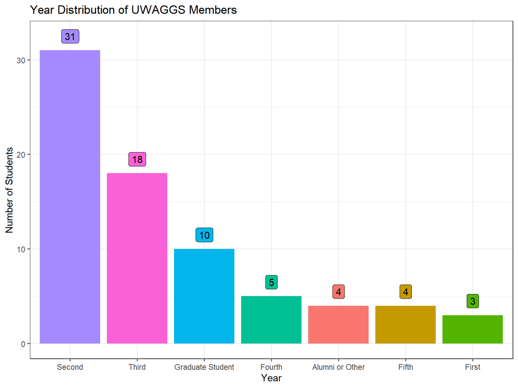

# UWAGGS Sports Interests

[interactive chart not shown]

# Goals for the Club

1. Form teams and collaborate on projects, hackathons, and competitions
2. Share resources for tutorials and workshops to enhance our breadth of data science applications to sport
3. Attend seminars from respected members of the sports analytics community
4. Present research at and attend conferences

# Goal 1: Projects, Hackathons, and Competitions

Examples:

- [Miluwakee Bucks - Analytics Hackathon](https://www.nba.com/bucks/hackathon): Basketball
- [LINHAC](https://www.ida.liu.se/research/sportsanalytics/LINHAC/LINHAC23/studentcompetition.html): Hockey
- [Big Data Bowl](https://www.kaggle.com/competitions/nfl-big-data-bowl-2024/overview): Football
- [SMT Data Challenge](https://cdn.uconnectlabs.com/wp-content/uploads/sites/123/2023/03/SMT-Data-Challenge-2023-fkyer-2.0.pdf): Baseball
- [French Trot Horse Racing Forecasting Competition](https://canssiontario.utoronto.ca/workshops-conferences/french-trot-horse-racing/): Horse Racing
- [UCONN Sports Analytics Symposium Data Challenge](https://statds.org/events/ucsas2024/challenge.html): Gymnastics

Competitions are often divided into categories to promote parity between participants, such as a High School/Undergraduate category and a Graduate Student/Open category. Some take place annually, others more sporadically, but there’s always something going on. Some competitions take place over a weekend in true “hackathon” style, while others last for months. Projects unaffiliated with a competition provide greater freedom and flexibility for exploration and extension.

# Goal 2: Resources, Tutorials, and Workshops

Examples:

- [guideR](https://docs.google.com/spreadsheets/u/0/d/1LPe8xYduoep9qCrNzBGdJHaHZ8dnmdHNnu7UXZKzawU/htmlview): Sports analytics “bible”, an excellent starting place for those new to this.
- [UTSPAN Hour](https://sportsanalytics.sa.utoronto.ca/category/events/utspan-hour/): Weekly tutorial sessions
- [Sports Dataverse](https://www.sportsdataverse.org): A suite of R, Python, and Node.js packages for extracting and analyzing sports data
- [CRAN Task View: Sports Analytics](https://cran.r-project.org/web/views/SportsAnalytics.html): An overview of some prominent sports analytics packages available in R
- [Statsbomb Soccer Data](https://statsbomb.com/what-we-do/hub/free-data/): Free soccer data!

We will host some tutorials of our own as well, but will heavily encourage attending sessions held by other clubs to build connections and not reinvent the wheel.

# Goal 3: Seminars

Examples

- [SFU Virtual Seminar Series](http://www.sfu.ca/sportsanalytics/Seminars.html): Tomorrow at 1pm!
- [Invited Talks](https://cs.uwaterloo.ca/events/data-science-seminar-deploying-insights-from-puck-and-player-tracking-in-near-real-time)

With sufficient interest, the plan is to organize speakers from the sports analytics industry to present their work at different events. There are also plans for a joint Ontario sports analytics showcase hosted by the UTSPAN in Toronto in the Winter semester.

# Goal 4: Research

Examples:

- [Carnegie Mellon Sports Analytics Conference](https://www.stat.cmu.edu/cmsac/conference/2023/)
- [SABR Analytics Conference](https://sabr.org/analytics)
- [Sport Innovation (SPIN) Summit](https://www.sportscientistcanada.ca/en-CA/SPIN-Summit-2023)

These are tailored for students interested in attaining formal publications in journals and conference proceedings, or wanting to attend conferences to grow their knowledge and network. Great opportunity to meet industry professionals and hiring managers!

# Pause for Questions

# Club Internals

Logistical Planning for the Sustainability and Success of UWAGGS

# Shared Documents

1. [Deliverables](https://docs.google.com/document/d/1hMm7T5qFivaZizUzrMtHmQVDk-kbfy7fGuhNR_BraQg/edit?usp=sharing)

Purpose: Keep people up to date on conferences and competitions, as well as associated deadlines.

2. [Projects](https://docs.google.com/document/d/1iKoBHEqmhUdAQO1tqV7yC82_ecvYcBtVvS5864cAr6c/edit?usp=sharing)

Purpose: Avenue for students to join projects, or monitor the progress of existing projects.

3. [Collaboration Board](https://docs.google.com/document/d/1AWtAKGFowSwDV_gPKn48oTrHHS0lzZ3z3W3tCTuxx68/edit?usp=sharing)

Purpose: Purpose: To facilitate collaboration between students who would like to work on projects

4. [External Job Board](https://docs.google.com/document/d/17o2CCOTtkILFweeKXElLaKQWt6ukOE_q4t6-JnZFFuM/edit?usp=sharing)

Purpose: Mostly for external co-op positions, but could be extended for full-time positions as well.

# Club Positions to Fill

1. **Communications:**
- Post announcements on social media
- Update mailing list
- Moderate discord
- Maintain linktree
2. **Secretary**
- Maintain regular communication with each of the project leads
- Maintain shared documents
- Manage emails
- Post slides from tutorials/events to website
- Triage communication requests from emails
3. **Treasurer**
- Because WUSA said so and it will probably be important down the road
4. **Other People:**
- If anyone has experience starting up a club or has corresponded with WUSA in the past as an executive member of another club, please reach out to David. He needs help with constitution and internal structuring to get UWAGGS codified by WUSA.
- Session brainstormers would also be helpful!

# Pause for Questions Round 2

# Project Brainstorming

- Use sticky notes? Or a digital format like Jamboard? Anonymous or Named?

# Closing Remarks

- Next Meeting: Aiming for bi-weekly sessions
- Next Steps: We plan to make a Discord, start a website, create socials, linktree, and mailing list

# Networking Time

- Time for broccoli?